© Bản quyền thuộc về Quantopian Inc.  
© Bản quyền sửa đổi thuộc về AI Cafe¹  
Giấy phép [Creative Commons Attribution 4.0](https://creativecommons.org/licenses/by/4.0/legalcode).  
[Khuyến cáo](https://aicafe.one/khuyen-cao/)

# Moment thống kê - độ lệch (Skewness) và độ nhọn (Kurtosis)

By Evgenia "Jenny" Nitishinskaya, Maxwell Margenot, and Delaney Granizo-Mackenzie

Edited by AI Cafe¹

Đôi khi, trung bình và phương sai không đủ để mô tả một phân phối. Khi chúng ta tính toán phương sai, chúng ta bình phương các độ lệch xung quanh trung bình. Trong trường hợp các độ lệch lớn, chúng ta không biết liệu chúng có khả năng là dương hay âm. Đây là lúc độ lệch (skewness) và tính đối xứng của một phân phối trở nên quan trọng. Một phân phối được coi là *đối xứng* nếu các phần ở hai bên của trung bình là hình ảnh phản chiếu của nhau. Ví dụ, phân phối chuẩn là đối xứng. Phân phối chuẩn với trung bình $\mu$ và độ lệch chuẩn $\sigma$ được định nghĩa là $$ f(x) = \frac{1}{\sigma \sqrt{2 \pi}} e^{-\frac{(x - \mu)^2}{2 \sigma^2}} $$ Chúng ta có thể vẽ nó để xác nhận rằng nó là đối xứng:

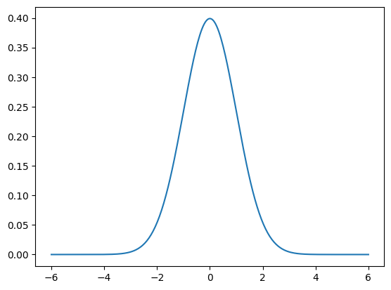

```python
import matplotlib.pyplot as plt
import numpy as np
import scipy.stats as stats

# Plot a normal distribution with mean = 0 and standard deviation = 2
xs = np.linspace(-6,6, 300)
normal = stats.norm.pdf(xs)
plt.plot(xs, normal);
```

## Độ lệch (Skewness)

Một phân phối không đối xứng được gọi là *độ lệch*. Ví dụ, một phân phối có thể có nhiều giá trị dương nhỏ và một vài giá trị âm lớn (độ lệch âm) hoặc ngược lại (độ lệch dương), và vẫn có trung bình bằng 0. Một phân phối đối xứng có độ lệch bằng 0. Các phân phối đơn cực (một cực) có độ lệch dương có đặc điểm là trung bình > trung vị > mode. Các phân phối đơn cực có độ lệch âm thì ngược lại, với trung bình < trung vị < mode. Tất cả ba giá trị này đều bằng nhau đối với một phân phối đơn cực đối xứng.

Công thức rõ ràng cho độ lệch là: $$ S_K = \frac{n}{(n-1)(n-2)} \frac{\sum_{i=1}^n (X_i - \mu)^3}{\sigma^3} $$

Trong đó $n$ là số lượng mẫu quan sát, $\mu$ là trung bình cộng, và $\sigma$ là độ lệch chuẩn. Dấu của giá trị này mô tả hướng của độ lệch như đã nêu ở trên. Chúng ta có thể vẽ một phân phối có độ lệch dương và một phân phối có độ lệch âm để xem chúng trông như thế nào. Đối với các phân phối đơn cực, một độ lệch âm thường chỉ ra rằng đuôi phân phối dày hơn bên trái, trong khi một độ lệch dương chỉ ra rằng đuôi phân phối dày hơn bên phải.

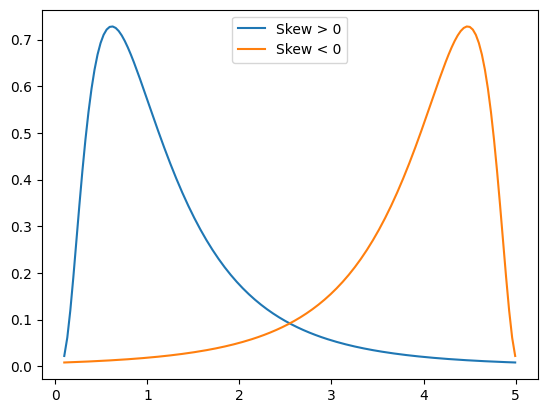

```python
# Generate x-values for which we will plot the distribution
xs2 = np.linspace(stats.lognorm.ppf(0.01, .7, loc=-.1), stats.lognorm.ppf(0.99, .7, loc=-.1), 150)

# Negatively skewed distribution
lognormal = stats.lognorm.pdf(xs2, .7)
plt.plot(xs2, lognormal, label='Skew > 0')

# Positively skewed distribution
plt.plot(xs2, lognormal[::-1], label='Skew < 0')
plt.legend();
```

Mặc dù độ lệch (skew) ít rõ ràng hơn khi vẽ đồ thị cho các tập dữ liệu rời rạc, chúng ta vẫn có thể tính toán nó. Ví dụ, dưới đây là độ lệch, trung bình, và trung vị cho lợi suất của FPT từ 2022 đến 2024. Lưu ý rằng độ lệch là dương, vì vậy trung bình sẽ lớn hơn trung vị.

```python
# Cài thư viện lấy dữ liệu miễn phí
!curl -fsSLO https://raw.githubusercontent.com/algo-stocks/data/master/data.py
```

```
Skew: [0.10809672]
Mean: 0.0014914703000009446
Median: 0.001046462699947126
```

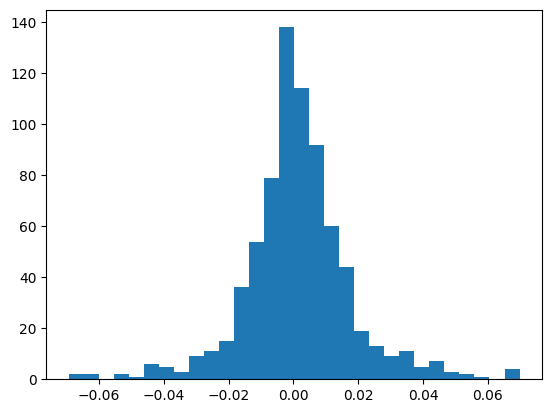

```python
from data import get_prices

start = '2022-01-01'
end = '2025-01-01'

prices = get_prices('FPT', start_date=start, end_date=end)
returns = prices.pct_change().dropna()

print('Skew:', stats.skew(returns))
print('Mean:', np.mean(returns))
print('Median:', np.median(returns))

plt.hist(returns, 30);
```

## Độ nhọn (Kurtosis)

Độ nhọn cố gắng đo lường hình dạng của sự lệch khỏi trung bình. Thông thường, nó mô tả độ nhọn của một phân phối so với phân phối chuẩn, được gọi là mesokurtic. Tất cả các phân phối chuẩn, bất kể trung bình và phương sai, đều có độ nhọn bằng 3. Một phân phối leptokurtic (độ nhọn > 3) có đỉnh cao và có đuôi dày, trong khi một phân phối platykurtic (độ nhọn < 3) thì rộng. Tuy nhiên, đôi khi độ nhọn vượt quá phân phối chuẩn (độ nhọn - 3) được sử dụng, và đây là cài đặt mặc định trong `scipy`. Một phân phối leptokurtic có nhiều lần nhảy lớn ra khỏi trung bình hơn so với phân phối chuẩn, trong khi một phân phối platykurtic có ít lần nhảy hơn.

```
Excess kurtosis of leptokurtic distribution: 3.0
Excess kurtosis of mesokurtic distribution: 0.0
Excess kurtosis of platykurtic distribution: -0.5937628755982794
```

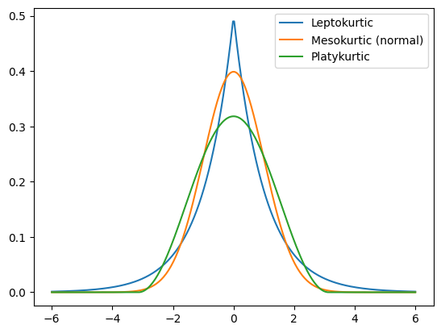

```python
# Plot some example distributions
plt.plot(xs,stats.laplace.pdf(xs), label='Leptokurtic')
print('Excess kurtosis of leptokurtic distribution:', (stats.laplace.stats(moments='k')))
plt.plot(xs, normal, label='Mesokurtic (normal)')
print('Excess kurtosis of mesokurtic distribution:', (stats.norm.stats(moments='k')))
plt.plot(xs,stats.cosine.pdf(xs), label='Platykurtic')
print('Excess kurtosis of platykurtic distribution:', (stats.cosine.stats(moments='k')))
plt.legend();
```

Công thức tính độ nhọn là $$ K = \left ( \frac{n(n+1)}{(n-1)(n-2)(n-3)} \frac{\sum_{i=1}^n (X_i - \mu)^4}{\sigma^4} \right ) $$

trong khi độ nhọn vượt mức được tính theo $$ K_E = \left ( \frac{n(n+1)}{(n-1)(n-2)(n-3)} \frac{\sum_{i=1}^n (X_i - \mu)^4}{\sigma^4} \right ) - \frac{3(n-1)^2}{(n-2)(n-3)} $$

Với tập mẫu lớn, độ nhọn vượt mức được tính xấp xỉ

$$ K_E \approx \frac{1}{n} \frac{\sum_{i=1}^n (X_i - \mu)^4}{\sigma^4} - 3 $$

Vì chúng ta đã xem xét các phân phối hoàn hảo, liên tục ở trên, đây là dạng mà kurtosis xuất hiện. Tuy nhiên, đối với một tập hợp mẫu được rút ra từ phân phối chuẩn, chúng ta sẽ sử dụng định nghĩa đầu tiên, và kurtosis (vượt mức) chỉ khoảng 0.

Chúng ta có thể sử dụng `scipy` để tìm kurtosis vượt mức của lợi nhuận FPT từ trước.

```python
print("Excess kurtosis of returns: ", stats.kurtosis(returns))
```

```
Excess kurtosis of returns:  [3.13164315]
```

Giá trị này lớn hơn 0 rất nhiều, nên có thể thấy rằng phân phối lợi nhuận của FPT là leptokurtic

## Các Moment khác

Không phải ngẫu nhiên mà phương sai, độ lệch và độ nhọn có công thức tương tự. Chúng là những Moment đầu tiên và quan trọng nhất, trong đó Moment $k$ có công thức $$ \frac{E[(X - E[X])^k]}{\sigma^k} $$

Moment đầu tiên luôn là 0 $(E[X - E[X]] = E[X] - E[E[X]] = 0)$, vì vậy chúng ta chỉ quan tâm đến Moment thứ hai đến thứ tư. Tất cả các Moment đều là các số vô hướng mô tả phân phối, và đặc biệt có thể được sử dụng để định lượng mức độ gần với phân phối chuẩn (có các Moment $0, \sigma, 0, \sigma^2$) mà phân phối đó có.

## Kiểm định Tính Chuẩn sử dụng Jarque-Bera

Kiểm định Jarque-Bera là một bài kiểm định thống kê phổ biến nhằm so sánh xem dữ liệu mẫu có độ lệch và độ nhọn tương tự như một phân phối chuẩn hay không. Chúng ta có thể thực hiện kiểm định này trên lợi nhuận của FPT để tìm giá trị p cho việc chúng đến từ một phân phối chuẩn.

Giả thuyết null của bài kiểm định Jarque-Bera là dữ liệu đến từ một phân phối chuẩn. Chính vì vậy, nó có thể không phát hiện được một quá trình không chuẩn nếu bạn có giá trị p thấp. Để an toàn, tốt nhất là tăng ngưỡng khi sử dụng bài kiểm định này.

Hãy nhớ phải coi giá trị p như một giá trị nhị phân và không cố gắng suy diễn hay so sánh chúng. Chúng ta sẽ sử dụng ngưỡng 0.05 cho giá trị p của mình.

## Hiệu Chỉnh Kiểm định

Hãy nhớ rằng mỗi bài kiểm định được viết một chút khác nhau trên các ngôn ngữ lập trình khác nhau. Bạn có thể không biết liệu giả thuyết null hay giả thuyết thay thế mà dữ liệu được kiểm định đến từ một phân phối chuẩn. Khuyến khích bạn sử dụng ký hiệu `?` cộng với việc tìm kiếm trực tuyến để tìm tài liệu về bài kiểm định; hơn nữa, thường là một ý tưởng tốt để hiệu chỉnh một bài kiểm định bằng cách thử nó trên dữ liệu mô phỏng và đảm bảo nó đưa ra câu trả lời đúng. Hãy làm điều đó ngay bây giờ.

```python
from statsmodels.stats.stattools import jarque_bera

N = 1000
M = 1000

pvalues = np.ndarray((N))

for i in range(N):
    # Draw M samples from a normal distribution
    X = np.random.normal(0, 1, M);
    _, pvalue, _, _ = jarque_bera(X)
    pvalues[i] = pvalue

# count number of pvalues below our default 0.05 cutoff
num_significant = len(pvalues[pvalues < 0.05])

print(float(num_significant) / N)
```

```
0.05
```

Tuyệt vời, nếu được hiệu chỉnh đúng cách, chúng ta nên mong đợi sai sót 5% trong tổng số kiểm định ở mức ý nghĩa 0.05, và điều này khá gần với thực tế. Điều này có nghĩa là bài kiểm định đang hoạt động như chúng ta mong đợi.

```python
_, pvalue, _, _ = jarque_bera(returns)

if pvalue > 0.05:
    print('The returns are likely normal.')
else:
    print('The returns are likely not normal.')
```

```
The returns are likely not normal.
```

Kết quả kiểm định cho thấy lợi nhuận của FPT không tuân theo phân phối chuẩn

*Lưu ý: Tài liệu này mang tính chất chia sẻ kiến thức khoa học dữ liệu. Các mã chứng khoán xuất hiện trong tài liệu chỉ mang tính chất minh hoạ, không khuyến nghị đầu tư. Chúng tôi không chịu trách nhiệm trước mọi rủi ro nào do sử dụng tài liệu này.*